# Risk Factor Analysis

## Outcome Variable

**Outcome Variable:** pers_wast

## Predictor Variables

**Intervention Variable:** impsan

**Adjustment Set:**

- arm
- sex
- W_mage
- meducyrs
- feducyrs
- hhwealth_quart
- hfoodsec
- W_mhtcm
- W_mwtkg
- W_mbmi
- W_nrooms
- W_nchldlt5
- W_parity
- impfloor
- safeh20
- delta_W_mage
- delta_meducyrs
- delta_feducyrs
- delta_hhwealth_quart
- delta_hfoodsec
- delta_W_mhtcm
- delta_W_mwtkg
- delta_W_mbmi
- delta_W_nrooms
- delta_W_nchldlt5
- delta_W_parity
- delta_impfloor
- delta_safeh20

## Stratifying Variables

The analysis was stratified on these variable(s):

- agecat
- studyid
- country

## Data Summary

| agecat | studyid | country | impsan | pers_wast | n_cell | n |
| --- | --- | --- | --- | --- | --- | --- |
| 0-24 months | COHORTS | GUATEMALA | 1 | 0 | 72 | 768 |
| 0-24 months | COHORTS | GUATEMALA | 1 | 1 | 1 | 768 |
| 0-24 months | COHORTS | GUATEMALA | 0 | 0 | 666 | 768 |
| 0-24 months | COHORTS | GUATEMALA | 0 | 1 | 29 | 768 |
| 0-24 months | COHORTS | INDIA | 1 | 0 | 1473 | 4126 |
| 0-24 months | COHORTS | INDIA | 1 | 1 | 99 | 4126 |
| 0-24 months | COHORTS | INDIA | 0 | 0 | 2240 | 4126 |
| 0-24 months | COHORTS | INDIA | 0 | 1 | 314 | 4126 |
| 0-24 months | COHORTS | PHILIPPINES | 1 | 0 | 146 | 1118 |
| 0-24 months | COHORTS | PHILIPPINES | 1 | 1 | 3 | 1118 |
| 0-24 months | COHORTS | PHILIPPINES | 0 | 0 | 919 | 1118 |
| 0-24 months | COHORTS | PHILIPPINES | 0 | 1 | 50 | 1118 |
| 0-24 months | CONTENT | PERU | 1 | 0 | 201 | 215 |
| 0-24 months | CONTENT | PERU | 1 | 1 | 0 | 215 |
| 0-24 months | CONTENT | PERU | 0 | 0 | 14 | 215 |
| 0-24 months | CONTENT | PERU | 0 | 1 | 0 | 215 |
| 0-24 months | JiVitA-3 | BANGLADESH | 1 | 0 | 10746 | 15793 |
| 0-24 months | JiVitA-3 | BANGLADESH | 1 | 1 | 580 | 15793 |
| 0-24 months | JiVitA-3 | BANGLADESH | 0 | 0 | 4151 | 15793 |
| 0-24 months | JiVitA-3 | BANGLADESH | 0 | 1 | 316 | 15793 |
| 0-24 months | JiVitA-4 | BANGLADESH | 1 | 0 | 3770 | 5279 |
| 0-24 months | JiVitA-4 | BANGLADESH | 1 | 1 | 302 | 5279 |
| 0-24 months | JiVitA-4 | BANGLADESH | 0 | 0 | 1083 | 5279 |
| 0-24 months | JiVitA-4 | BANGLADESH | 0 | 1 | 124 | 5279 |
| 0-24 months | LCNI-5 | MALAWI | 1 | 0 | 3 | 711 |
| 0-24 months | LCNI-5 | MALAWI | 1 | 1 | 0 | 711 |
| 0-24 months | LCNI-5 | MALAWI | 0 | 0 | 702 | 711 |
| 0-24 months | LCNI-5 | MALAWI | 0 | 1 | 6 | 711 |
| 0-24 months | MAL-ED | BANGLADESH | 1 | 0 | 192 | 242 |
| 0-24 months | MAL-ED | BANGLADESH | 1 | 1 | 12 | 242 |

[output cut: 158 more lines]

The following strata were considered:

- agecat: 0-24 months, studyid: COHORTS, country: GUATEMALA
- agecat: 0-24 months, studyid: COHORTS, country: INDIA
- agecat: 0-24 months, studyid: COHORTS, country: PHILIPPINES
- agecat: 0-24 months, studyid: CONTENT, country: PERU
- agecat: 0-24 months, studyid: JiVitA-3, country: BANGLADESH
- agecat: 0-24 months, studyid: JiVitA-4, country: BANGLADESH
- agecat: 0-24 months, studyid: LCNI-5, country: MALAWI
- agecat: 0-24 months, studyid: MAL-ED, country: BANGLADESH
- agecat: 0-24 months, studyid: MAL-ED, country: BRAZIL
- agecat: 0-24 months, studyid: MAL-ED, country: INDIA
- agecat: 0-24 months, studyid: MAL-ED, country: NEPAL
- agecat: 0-24 months, studyid: MAL-ED, country: PERU
- agecat: 0-24 months, studyid: MAL-ED, country: SOUTH AFRICA
- agecat: 0-24 months, studyid: MAL-ED, country: TANZANIA, UNITED REPUBLIC OF
- agecat: 0-24 months, studyid: NIH-Birth, country: BANGLADESH
- agecat: 0-24 months, studyid: NIH-Crypto, country: BANGLADESH
- agecat: 0-24 months, studyid: PROVIDE, country: BANGLADESH
- agecat: 0-6 months, studyid: COHORTS, country: PHILIPPINES
- agecat: 0-6 months, studyid: CONTENT, country: PERU
- agecat: 0-6 months, studyid: JiVitA-3, country: BANGLADESH
- agecat: 0-6 months, studyid: MAL-ED, country: BANGLADESH
- agecat: 0-6 months, studyid: MAL-ED, country: BRAZIL
- agecat: 0-6 months, studyid: MAL-ED, country: INDIA
- agecat: 0-6 months, studyid: MAL-ED, country: NEPAL
- agecat: 0-6 months, studyid: MAL-ED, country: PERU
- agecat: 0-6 months, studyid: MAL-ED, country: SOUTH AFRICA
- agecat: 0-6 months, studyid: MAL-ED, country: TANZANIA, UNITED REPUBLIC OF
- agecat: 0-6 months, studyid: NIH-Birth, country: BANGLADESH
- agecat: 0-6 months, studyid: NIH-Crypto, country: BANGLADESH
- agecat: 0-6 months, studyid: PROVIDE, country: BANGLADESH
- agecat: 6-24 months, studyid: COHORTS, country: GUATEMALA
- agecat: 6-24 months, studyid: COHORTS, country: INDIA
- agecat: 6-24 months, studyid: COHORTS, country: PHILIPPINES
- agecat: 6-24 months, studyid: CONTENT, country: PERU
- agecat: 6-24 months, studyid: JiVitA-3, country: BANGLADESH
- agecat: 6-24 months, studyid: JiVitA-4, country: BANGLADESH
- agecat: 6-24 months, studyid: LCNI-5, country: MALAWI
- agecat: 6-24 months, studyid: MAL-ED, country: BANGLADESH
- agecat: 6-24 months, studyid: MAL-ED, country: BRAZIL
- agecat: 6-24 months, studyid: MAL-ED, country: INDIA
- agecat: 6-24 months, studyid: MAL-ED, country: NEPAL
- agecat: 6-24 months, studyid: MAL-ED, country: PERU
- agecat: 6-24 months, studyid: MAL-ED, country: SOUTH AFRICA
- agecat: 6-24 months, studyid: MAL-ED, country: TANZANIA, UNITED REPUBLIC OF
- agecat: 6-24 months, studyid: NIH-Birth, country: BANGLADESH
- agecat: 6-24 months, studyid: NIH-Crypto, country: BANGLADESH
- agecat: 6-24 months, studyid: PROVIDE, country: BANGLADESH

### Dropped Strata

Some strata were dropped due to rare outcomes:

- agecat: 0-24 months, studyid: COHORTS, country: GUATEMALA
- agecat: 0-24 months, studyid: COHORTS, country: PHILIPPINES
- agecat: 0-24 months, studyid: CONTENT, country: PERU
- agecat: 0-24 months, studyid: LCNI-5, country: MALAWI
- agecat: 0-24 months, studyid: MAL-ED, country: BANGLADESH
- agecat: 0-24 months, studyid: MAL-ED, country: BRAZIL
- agecat: 0-24 months, studyid: MAL-ED, country: NEPAL
- agecat: 0-24 months, studyid: MAL-ED, country: PERU
- agecat: 0-24 months, studyid: MAL-ED, country: SOUTH AFRICA
- agecat: 0-24 months, studyid: MAL-ED, country: TANZANIA, UNITED REPUBLIC OF
- agecat: 0-24 months, studyid: PROVIDE, country: BANGLADESH
- agecat: 0-6 months, studyid: COHORTS, country: PHILIPPINES
- agecat: 0-6 months, studyid: CONTENT, country: PERU
- agecat: 0-6 months, studyid: JiVitA-3, country: BANGLADESH
- agecat: 0-6 months, studyid: MAL-ED, country: BANGLADESH
- agecat: 0-6 months, studyid: MAL-ED, country: BRAZIL
- agecat: 0-6 months, studyid: MAL-ED, country: NEPAL
- agecat: 0-6 months, studyid: MAL-ED, country: PERU
- agecat: 0-6 months, studyid: MAL-ED, country: SOUTH AFRICA
- agecat: 0-6 months, studyid: MAL-ED, country: TANZANIA, UNITED REPUBLIC OF
- agecat: 0-6 months, studyid: NIH-Birth, country: BANGLADESH
- agecat: 0-6 months, studyid: NIH-Crypto, country: BANGLADESH
- agecat: 0-6 months, studyid: PROVIDE, country: BANGLADESH
- agecat: 6-24 months, studyid: COHORTS, country: GUATEMALA
- agecat: 6-24 months, studyid: COHORTS, country: PHILIPPINES
- agecat: 6-24 months, studyid: CONTENT, country: PERU
- agecat: 6-24 months, studyid: LCNI-5, country: MALAWI
- agecat: 6-24 months, studyid: MAL-ED, country: BANGLADESH
- agecat: 6-24 months, studyid: MAL-ED, country: BRAZIL
- agecat: 6-24 months, studyid: MAL-ED, country: NEPAL
- agecat: 6-24 months, studyid: MAL-ED, country: PERU
- agecat: 6-24 months, studyid: MAL-ED, country: SOUTH AFRICA
- agecat: 6-24 months, studyid: MAL-ED, country: TANZANIA, UNITED REPUBLIC OF
- agecat: 6-24 months, studyid: PROVIDE, country: BANGLADESH

## Methods Detail

We’re interested in the causal parameters $E[Y_a]$ for all values of $a \in \mathcal{A}$. These parameters represent the mean outcome if, possibly contrary to fact, we intervened to set all units to have $A=a$. Under the randomization and positivity assumptions, these are identified by the statistical parameters $\psi_a=E_W[E_{Y|A,W}(Y|A=a,W)]$. In addition, we’re interested in the mean of $Y$, $E[Y]$ under no intervention (the observed mean). We will estimate these parameters by using SuperLearner to fit the relevant likelihood factors – $E_{Y|A,W}(Y|A=a,W)$ and $p(A=a|W)$, and then updating our likelihood fit using a joint TMLE.

For unadjusted analyses ($W=\{\}$), initial likelihoods were estimated using Lrnr_glm to estimate the simple $E(Y|A)$ and Lrnr_mean to estimate $p(A)$. For adjusted analyses, a small library containing Lrnr_glmnet, Lrnr_xgboost, and Lrnr_mean was used.

Having estimated these parameters, we will then use the delta method to estimate relative risks and attributable risks relative to a prespecified baseline level of $A$.

# Results Detail

## Results Plots

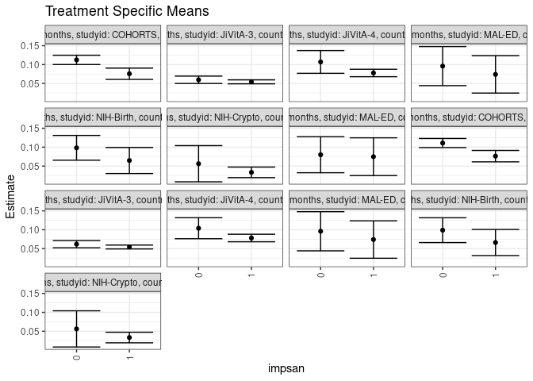

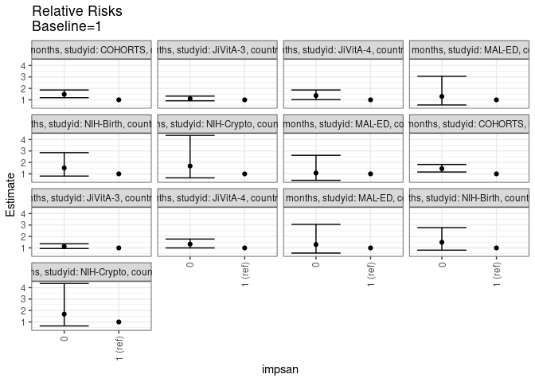

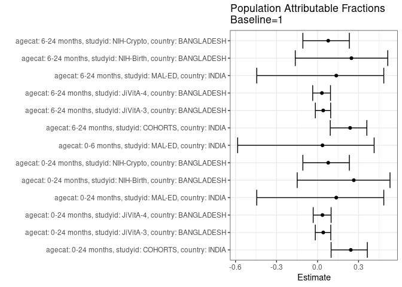

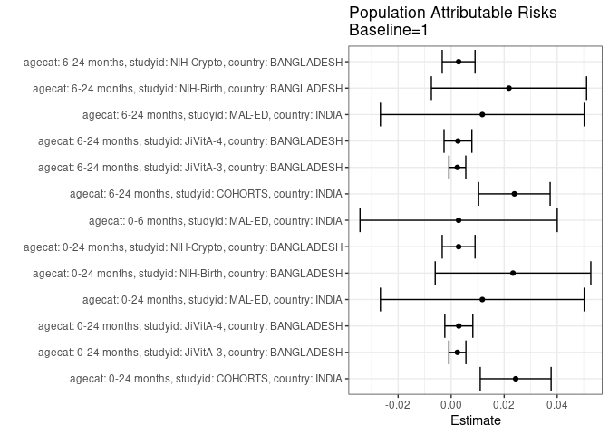

## Results Table

### Parameter: TSM

| agecat | studyid | country | intervention_level | baseline_level | estimate | ci_lower | ci_upper |
| --- | --- | --- | --- | --- | --- | --- | --- |
| 0-24 months | COHORTS | INDIA | 1 | NA | 0.0757526 | 0.0608230 | 0.0906822 |
| 0-24 months | COHORTS | INDIA | 0 | NA | 0.1124318 | 0.1001631 | 0.1247004 |
| 0-24 months | JiVitA-3 | BANGLADESH | 1 | NA | 0.0543602 | 0.0491223 | 0.0595981 |
| 0-24 months | JiVitA-3 | BANGLADESH | 0 | NA | 0.0597582 | 0.0499918 | 0.0695247 |
| 0-24 months | JiVitA-4 | BANGLADESH | 1 | NA | 0.0777975 | 0.0679055 | 0.0876895 |
| 0-24 months | JiVitA-4 | BANGLADESH | 0 | NA | 0.1070129 | 0.0768615 | 0.1371644 |
| 0-24 months | MAL-ED | INDIA | 1 | NA | 0.0740741 | 0.0245756 | 0.1235725 |
| 0-24 months | MAL-ED | INDIA | 0 | NA | 0.0960000 | 0.0442456 | 0.1477544 |
| 0-24 months | NIH-Birth | BANGLADESH | 1 | NA | 0.0646728 | 0.0301927 | 0.0991530 |
| 0-24 months | NIH-Birth | BANGLADESH | 0 | NA | 0.0982299 | 0.0654505 | 0.1310093 |
| 0-24 months | NIH-Crypto | BANGLADESH | 1 | NA | 0.0333333 | 0.0193066 | 0.0473601 |
| 0-24 months | NIH-Crypto | BANGLADESH | 0 | NA | 0.0561798 | 0.0083069 | 0.1040527 |
| 0-6 months | MAL-ED | INDIA | 1 | NA | 0.0747664 | 0.0248235 | 0.1247092 |
| 0-6 months | MAL-ED | INDIA | 0 | NA | 0.0800000 | 0.0323382 | 0.1276618 |
| 6-24 months | COHORTS | INDIA | 1 | NA | 0.0762382 | 0.0611699 | 0.0913065 |
| 6-24 months | COHORTS | INDIA | 0 | NA | 0.1109487 | 0.0989489 | 0.1229484 |
| 6-24 months | JiVitA-3 | BANGLADESH | 1 | NA | 0.0543804 | 0.0492634 | 0.0594973 |
| 6-24 months | JiVitA-3 | BANGLADESH | 0 | NA | 0.0618218 | 0.0523209 | 0.0713226 |
| 6-24 months | JiVitA-4 | BANGLADESH | 1 | NA | 0.0781244 | 0.0681911 | 0.0880577 |
| 6-24 months | JiVitA-4 | BANGLADESH | 0 | NA | 0.1039766 | 0.0761857 | 0.1317676 |
| 6-24 months | MAL-ED | INDIA | 1 | NA | 0.0740741 | 0.0245756 | 0.1235725 |
| 6-24 months | MAL-ED | INDIA | 0 | NA | 0.0960000 | 0.0442456 | 0.1477544 |
| 6-24 months | NIH-Birth | BANGLADESH | 1 | NA | 0.0662001 | 0.0316840 | 0.1007162 |
| 6-24 months | NIH-Birth | BANGLADESH | 0 | NA | 0.0988319 | 0.0660453 | 0.1316185 |
| 6-24 months | NIH-Crypto | BANGLADESH | 1 | NA | 0.0333333 | 0.0193066 | 0.0473601 |
| 6-24 months | NIH-Crypto | BANGLADESH | 0 | NA | 0.0561798 | 0.0083069 | 0.1040527 |

### Parameter: E(Y)

| agecat | studyid | country | intervention_level | baseline_level | estimate | ci_lower | ci_upper |
| --- | --- | --- | --- | --- | --- | --- | --- |
| 0-24 months | COHORTS | INDIA | NA | NA | 0.1000969 | 0.0909380 | 0.1092559 |
| 0-24 months | JiVitA-3 | BANGLADESH | NA | NA | 0.0567340 | 0.0526185 | 0.0608495 |
| 0-24 months | JiVitA-4 | BANGLADESH | NA | NA | 0.0806971 | 0.0720842 | 0.0893100 |
| 0-24 months | MAL-ED | INDIA | NA | NA | 0.0858369 | 0.0497913 | 0.1218826 |
| 0-24 months | NIH-Birth | BANGLADESH | NA | NA | 0.0880150 | 0.0639627 | 0.1120673 |
| 0-24 months | NIH-Crypto | BANGLADESH | NA | NA | 0.0361613 | 0.0225058 | 0.0498169 |
| 0-6 months | MAL-ED | INDIA | NA | NA | 0.0775862 | 0.0430879 | 0.1120845 |
| 6-24 months | COHORTS | INDIA | NA | NA | 0.1000969 | 0.0909380 | 0.1092559 |
| 6-24 months | JiVitA-3 | BANGLADESH | NA | NA | 0.0567340 | 0.0526185 | 0.0608495 |
| 6-24 months | JiVitA-4 | BANGLADESH | NA | NA | 0.0806971 | 0.0720842 | 0.0893100 |
| 6-24 months | MAL-ED | INDIA | NA | NA | 0.0858369 | 0.0497913 | 0.1218826 |
| 6-24 months | NIH-Birth | BANGLADESH | NA | NA | 0.0880150 | 0.0639627 | 0.1120673 |
| 6-24 months | NIH-Crypto | BANGLADESH | NA | NA | 0.0361613 | 0.0225058 | 0.0498169 |

### Parameter: RR

| agecat | studyid | country | intervention_level | baseline_level | estimate | ci_lower | ci_upper |
| --- | --- | --- | --- | --- | --- | --- | --- |
| 0-24 months | COHORTS | INDIA | 1 | 1 | 1.000000 | 1.0000000 | 1.000000 |
| 0-24 months | COHORTS | INDIA | 0 | 1 | 1.484197 | 1.1855068 | 1.858143 |
| 0-24 months | JiVitA-3 | BANGLADESH | 1 | 1 | 1.000000 | 1.0000000 | 1.000000 |
| 0-24 months | JiVitA-3 | BANGLADESH | 0 | 1 | 1.099301 | 0.9110181 | 1.326497 |
| 0-24 months | JiVitA-4 | BANGLADESH | 1 | 1 | 1.000000 | 1.0000000 | 1.000000 |
| 0-24 months | JiVitA-4 | BANGLADESH | 0 | 1 | 1.375531 | 1.0175533 | 1.859447 |
| 0-24 months | MAL-ED | INDIA | 1 | 1 | 1.000000 | 1.0000000 | 1.000000 |
| 0-24 months | MAL-ED | INDIA | 0 | 1 | 1.296000 | 0.5491950 | 3.058324 |
| 0-24 months | NIH-Birth | BANGLADESH | 1 | 1 | 1.000000 | 1.0000000 | 1.000000 |
| 0-24 months | NIH-Birth | BANGLADESH | 0 | 1 | 1.518875 | 0.8084291 | 2.853658 |
| 0-24 months | NIH-Crypto | BANGLADESH | 1 | 1 | 1.000000 | 1.0000000 | 1.000000 |
| 0-24 months | NIH-Crypto | BANGLADESH | 0 | 1 | 1.685393 | 0.6515657 | 4.359577 |
| 0-6 months | MAL-ED | INDIA | 1 | 1 | 1.000000 | 1.0000000 | 1.000000 |
| 0-6 months | MAL-ED | INDIA | 0 | 1 | 1.070000 | 0.4371800 | 2.618830 |
| 6-24 months | COHORTS | INDIA | 1 | 1 | 1.000000 | 1.0000000 | 1.000000 |
| 6-24 months | COHORTS | INDIA | 0 | 1 | 1.455289 | 1.1624047 | 1.821970 |
| 6-24 months | JiVitA-3 | BANGLADESH | 1 | 1 | 1.000000 | 1.0000000 | 1.000000 |
| 6-24 months | JiVitA-3 | BANGLADESH | 0 | 1 | 1.136840 | 0.9513852 | 1.358445 |
| 6-24 months | JiVitA-4 | BANGLADESH | 1 | 1 | 1.000000 | 1.0000000 | 1.000000 |
| 6-24 months | JiVitA-4 | BANGLADESH | 0 | 1 | 1.330911 | 0.9979577 | 1.774949 |
| 6-24 months | MAL-ED | INDIA | 1 | 1 | 1.000000 | 1.0000000 | 1.000000 |
| 6-24 months | MAL-ED | INDIA | 0 | 1 | 1.296000 | 0.5491950 | 3.058324 |
| 6-24 months | NIH-Birth | BANGLADESH | 1 | 1 | 1.000000 | 1.0000000 | 1.000000 |
| 6-24 months | NIH-Birth | BANGLADESH | 0 | 1 | 1.492926 | 0.8035929 | 2.773579 |
| 6-24 months | NIH-Crypto | BANGLADESH | 1 | 1 | 1.000000 | 1.0000000 | 1.000000 |
| 6-24 months | NIH-Crypto | BANGLADESH | 0 | 1 | 1.685393 | 0.6515657 | 4.359577 |

### Parameter: PAR

| agecat | studyid | country | intervention_level | baseline_level | estimate | ci_lower | ci_upper |
| --- | --- | --- | --- | --- | --- | --- | --- |
| 0-24 months | COHORTS | INDIA | 1 | NA | 0.0243444 | 0.0109734 | 0.0377154 |
| 0-24 months | JiVitA-3 | BANGLADESH | 1 | NA | 0.0023738 | -0.0008316 | 0.0055792 |
| 0-24 months | JiVitA-4 | BANGLADESH | 1 | NA | 0.0028996 | -0.0023903 | 0.0081895 |
| 0-24 months | MAL-ED | INDIA | 1 | NA | 0.0117628 | -0.0266826 | 0.0502083 |
| 0-24 months | NIH-Birth | BANGLADESH | 1 | NA | 0.0233422 | -0.0060137 | 0.0526980 |
| 0-24 months | NIH-Crypto | BANGLADESH | 1 | NA | 0.0028280 | -0.0033715 | 0.0090275 |
| 0-6 months | MAL-ED | INDIA | 1 | NA | 0.0028199 | -0.0343776 | 0.0400173 |
| 6-24 months | COHORTS | INDIA | 1 | NA | 0.0238587 | 0.0103716 | 0.0373459 |
| 6-24 months | JiVitA-3 | BANGLADESH | 1 | NA | 0.0023536 | -0.0008218 | 0.0055291 |
| 6-24 months | JiVitA-4 | BANGLADESH | 1 | NA | 0.0025727 | -0.0026778 | 0.0078232 |
| 6-24 months | MAL-ED | INDIA | 1 | NA | 0.0117628 | -0.0266826 | 0.0502083 |
| 6-24 months | NIH-Birth | BANGLADESH | 1 | NA | 0.0218149 | -0.0074615 | 0.0510912 |
| 6-24 months | NIH-Crypto | BANGLADESH | 1 | NA | 0.0028280 | -0.0033715 | 0.0090275 |

### Parameter: PAF

| agecat | studyid | country | intervention_level | baseline_level | estimate | ci_lower | ci_upper |
| --- | --- | --- | --- | --- | --- | --- | --- |
| 0-24 months | COHORTS | INDIA | 1 | NA | 0.2432079 | 0.0992246 | 0.3641763 |
| 0-24 months | JiVitA-3 | BANGLADESH | 1 | NA | 0.0418406 | -0.0164704 | 0.0968066 |
| 0-24 months | JiVitA-4 | BANGLADESH | 1 | NA | 0.0359316 | -0.0318264 | 0.0992402 |
| 0-24 months | MAL-ED | INDIA | 1 | NA | 0.1370370 | -0.4448822 | 0.4845911 |
| 0-24 months | NIH-Birth | BANGLADESH | 1 | NA | 0.2652066 | -0.1489544 | 0.5300760 |
| 0-24 months | NIH-Crypto | BANGLADESH | 1 | NA | 0.0782051 | -0.1073443 | 0.2326634 |
| 0-6 months | MAL-ED | INDIA | 1 | NA | 0.0363448 | -0.5844823 | 0.4139212 |
| 6-24 months | COHORTS | INDIA | 1 | NA | 0.2383563 | 0.0929467 | 0.3604553 |
| 6-24 months | JiVitA-3 | BANGLADESH | 1 | NA | 0.0414852 | -0.0161355 | 0.0958384 |
| 6-24 months | JiVitA-4 | BANGLADESH | 1 | NA | 0.0318809 | -0.0353912 | 0.0947822 |
| 6-24 months | MAL-ED | INDIA | 1 | NA | 0.1370370 | -0.4448822 | 0.4845911 |
| 6-24 months | NIH-Birth | BANGLADESH | 1 | NA | 0.2478540 | -0.1629005 | 0.5135236 |
| 6-24 months | NIH-Crypto | BANGLADESH | 1 | NA | 0.0782051 | -0.1073443 | 0.2326634 |